# Introduction

The purpose of this project was to determine whether hindlimb length varies between ecomorphs within the genus *Anolis*. We utilized visualization techniques in order to accomplish yhis. By using a phylogenetic tree of 46 species of anole lizards (Poe et al. 2017) and analyzing morphological and ecomorphological data of these species (Hagey et al. 2017), it was determined that hind limb length does vary with phylogenetic relationship, not simply allometry. This project also served as a springboard to explore more sophisticated operations with `tidyverse` as well as an introduction to working with data that may have a relationship due to phylogeny.

[figure not shown]

# Methods

The data sets obtained from Hagey et al. (2017) were log transformed and two linear models were constructed in order to assess the effect of perch height and diameter on hindlimb length. The residuals of these data were calculated and plotted against the discrete factors in order to discover how both perch diameter and height affect the hindlimb-SVL relationship. The anole phylogenetic tree from Poe et al. (2017) was used to construct phylogenetic least squares models of the hindlimb-SVL relationships using all possible combinations of the two covariates:

- PGLS model with the hindlimb-SVL relationship + perch height
- PGLS model with the hindlimb-SVL relationship + perch diameter
- PGLS model with the hindlimb-SVL relationship + perch height + perch diameter

The fit of each model was assessed using AICc and AICw in order to determine whether one or both of the covariates is a significant predictor of hindlimb length in a phylogenetic context. A facet grid was produced from the best fitting PGLS model in order to visualize the effect of perch height, perch diameter, and ecomorph on the hindlimb residuals.

# Results

```r
# Join tables, filter, mutate to log
anole.log <- anole %>%
    left_join(anole.eco)%>%
    filter(!Ecomorph%in%c("U","CH"))%>%
    na.omit()%>%
    mutate_at(c("SVL", "HTotal","PH","ArbPD"),log)
# Phylogenetic least squares models using a BM model of trait evolution
# A PGLS model with the hindlimb-SVL relationship + perch height
pgls.BM.ph <- gls(HTotal~SVL + PH,correlation = corBrownian(1, phy = anole.tree, form =~Species),data= anole.log, method = 'ML')

# A PGLS model with the hindlimb-SVL relationship + perch diameter
pgls.BM.pd <- gls(HTotal~SVL + ArbPD,correlation = corBrownian(1, phy = anole.tree, form =~Species),data= anole.log, method = 'ML')

# A PGLS model with the hindlimb-SVL relationship + perch height + perch diameter
pgls.BM.ph.pd <- gls(HTotal~SVL + PH + ArbPD, correlation = corBrownian(1, phy = anole.tree, form =~Species), data= anole.log, method = 'ML')
```

```r
# AIC operations
anole.phylo.aic <- MuMIn::AICc(pgls.BM.ph, pgls.BM.pd, pgls.BM.ph.pd)
anole.phylow.aicw <- aicw(anole.phylo.aic$AICc)
```

```r
# Table of AIC values using Kable

n.spec <- anole.phylo.aic%>%
  group_by(rownames(anole.phylo.aic))%>%
  summarise(AIC = AICc)
n.spec%>%
  kable(caption = "AIC Values for Various PGLS Models of the hindlimb-SVL relationship with Perch Height and Diameter")
```

AIC Values for Various PGLS Models of the hindlimb-SVL relationship with Perch Height and Diameter

| rownames(anole.phylo.aic) | AIC |
| --- | --- |
| pgls.BM.pd | -73.81081 |
| pgls.BM.ph | -64.77956 |
| pgls.BM.ph.pd | -75.52571 |

```r
# Add phylo-corrected residuals
anole.log <- anole.log%>%
  mutate(phylo.res=residuals(pgls.BM.ph.pd),
         res.ph=residuals(pgls.BM.ph),
         res.pd=residuals(pgls.BM.pd))
```

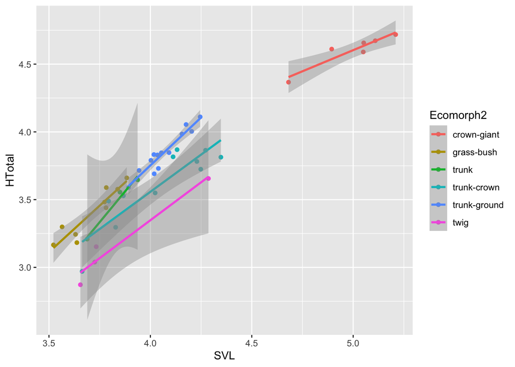

```r
# Plot log-transformed HTotal vs. SVL
anole.log%>%
  ggplot(aes(SVL,HTotal,col=Ecomorph2))+geom_point()+geom_smooth(method="lm")
```

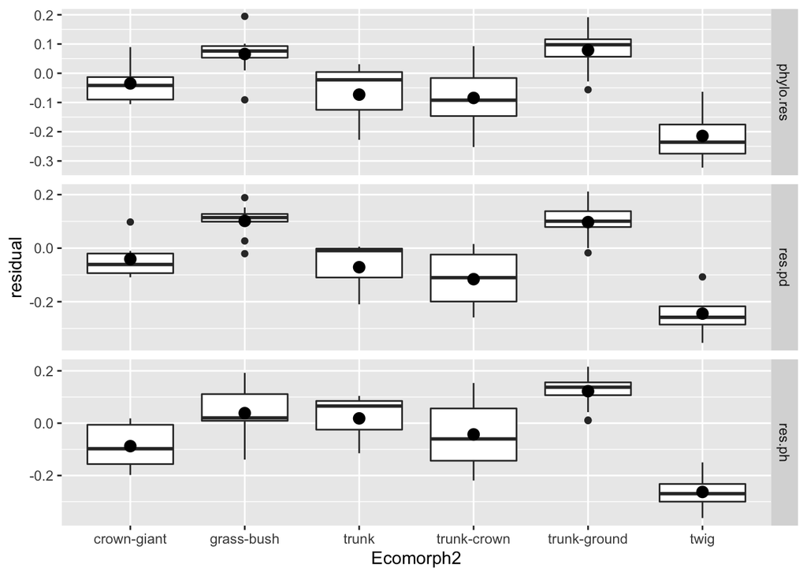

Boxplot of phylogenetically-corrected hindlimb residuals vs. anole ecomorph with perch height and diameter

```r
# Plot residuals
anole.log %>%
    dplyr::select(Ecomorph2,res.ph,res.pd,phylo.res) %>%
    pivot_longer(cols = c("res.ph","res.pd", "phylo.res"))%>%
    ggplot(aes(x = Ecomorph2,y = value)) +
    geom_boxplot() +
    stat_summary(fun=mean, geom="point", size=3)+
    facet_grid(name~.,scales = "free_y") + ylab("residual")
```

# Discussion

# Author Contributions

Justin Lau - Questions 2,4,5,6

Liz Asprinio - Introduction, Methods, Revisions

Michael Britt - Introduction, Discussion, Revisions/Edits (Grammar)

Katherine Quinlivan - Introduction, Discussion, Edits and Tidying

# CPK comments:

Hagey, Travis J, Scott Harte, Mathew Vickers, Luke J Harmon, and Lin Schwarzkopf. 2017. “There’s More Than One Way to Climb a Tree: Limb Length and Microhabitat Use in Lizards with Toe Pads.” *PloS One* 12 (9): e0184641.

Poe, Steven, Adrian Nieto-Montes de Oca, Omar Torres-Carvajal, Kevin De Queiroz, Julián A Velasco, Brad Truett, Levi N Gray, et al. 2017. “A Phylogenetic, Biogeographic, and Taxonomic Study of All Extant Species of Anolis (Squamata; Iguanidae).” *Systematic Biology* 66 (5): 663–97.